# Lab 6: Mixed-effects models in Stan

2023-07-20

## Streams revisited, but in Stan

Today, we are going to revisit the Streams dataset again (ugh - Streams again? - yes!). We’ve fit this model before in `nlme()` but now we want to see how a similar approach would work in Stan.

Now lets read in our dataset.

```r
Streams <- readRDS(file="Data/streams.rds")
colnames(Streams) <- c("Stream","true_density","Density")
```

We know that we want to get an equation that looks something like: $y_{i,j} = \beta + b_{j} + \epsilon_i$ where $\beta$ is the stream-level average density, $\epsilon_i ~ N(0,\sigma_E)$ is normally distributed error with standard deviation $\sigma_E$ and the stream-level random effects are $b_{j} ~ N(0,\sigma_S)$ where $\sigma_S$ is the standard deviation among streams.

Let’s try to fit this in Stan. First, we create our dataset as a list. Next, we will set some starting parameters. Last, we will switch over to Stan.

```r
stan_data <- list("N"=nrow(Streams),
                  "y"=Streams$Density,
                  "Nstreams"=length(unique(Streams$Stream)),
                  "stream_id"=as.numeric(Streams$Stream))

init_fx <- function(chain_id)
{
  list("beta" = mean(Streams$Stream),
       "sigma_stream"=1,
       "sigma"=1)
}

fit <- rstan::stan(file = "Labs/Lab 6/Lab 6.stan",
                   data = stan_data,
                   iter = 2000,
                   chains = 4,
                   init = init_fx)
post_summ <- summary(fit,pars=c("beta","sigma_stream","sigma"),probs=c(0.025,0.975))$summary
print(post_summ)
```

```
##                 mean  se_mean     sd    2.5%   97.5%  n_eff   Rhat
## beta         78.5009 0.137176 4.1977 70.3450 87.1165  936.4 1.0031
## sigma_stream  9.5146 0.040438 1.8697  6.1943 13.7242 2137.8 1.0004
## sigma         5.8657 0.026081 1.1405  4.1649  8.6695 1912.1 1.0006
```

```r
summary(fit,pars=c("stream_effect"))$summary
```

```
##                    mean  se_mean     sd   2.5%    25%    50%    75%   97.5%
## stream_effect[1] 93.250 0.059361 3.6114 85.556 91.002 93.375 95.639 100.020
## stream_effect[2] 89.879 0.055423 3.4190 82.922 87.762 89.990 92.205  96.247
## stream_effect[3] 88.769 0.053240 3.3474 81.969 86.598 88.843 91.041  95.044
## stream_effect[4] 68.876 0.049903 3.3886 62.472 66.598 68.777 70.961  75.989
## stream_effect[5] 73.008 0.046799 3.2790 66.582 70.877 73.004 75.171  79.319
## stream_effect[6] 57.893 0.067287 3.6249 51.292 55.546 57.652 60.011  65.674
##                   n_eff    Rhat
## stream_effect[1] 3701.2 0.99917
## stream_effect[2] 3805.5 0.99933
## stream_effect[3] 3953.1 0.99998
## stream_effect[4] 4610.9 0.99913
## stream_effect[5] 4909.3 0.99971
## stream_effect[6] 2902.2 0.99984
```

Now lets plot this to the true densities from the original data. Note here that the stream effects, in actual density per stream, is: $\beta_j=\beta + b_j$

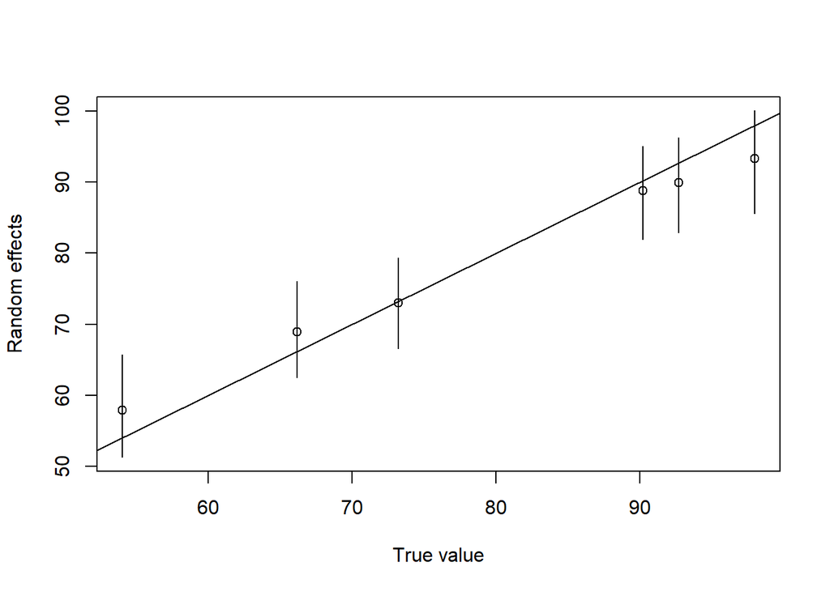

```r
true_density <- as.numeric(unique(Streams$true_density))
stream_eff <- rstan::extract(fit)$stream_effect
ci <- apply(stream_eff,2,function(x){c(mean(x),quantile(x,probs=c(0.025,0.975)))})

plot(true_density,ci[1,],ylim=range(ci),xlab="True value",ylab="Random effects") # extract the stream-level effects (fixed effect + random effects) and compare to true values
segments(x0=true_density,y0=ci[2,],y1=ci[3,])
points(true_density,ci[1,])
abline(b=1,a=0) # add a 1:1 line for comparison
```

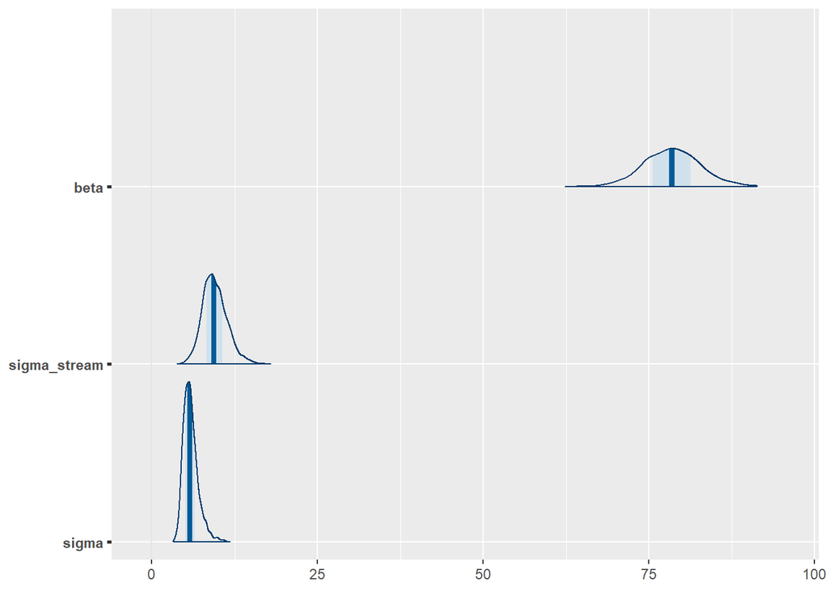

```r
posterior <- as.array(fit)
bayesplot::mcmc_areas(posterior, pars = c("beta","sigma_stream","sigma"))
```

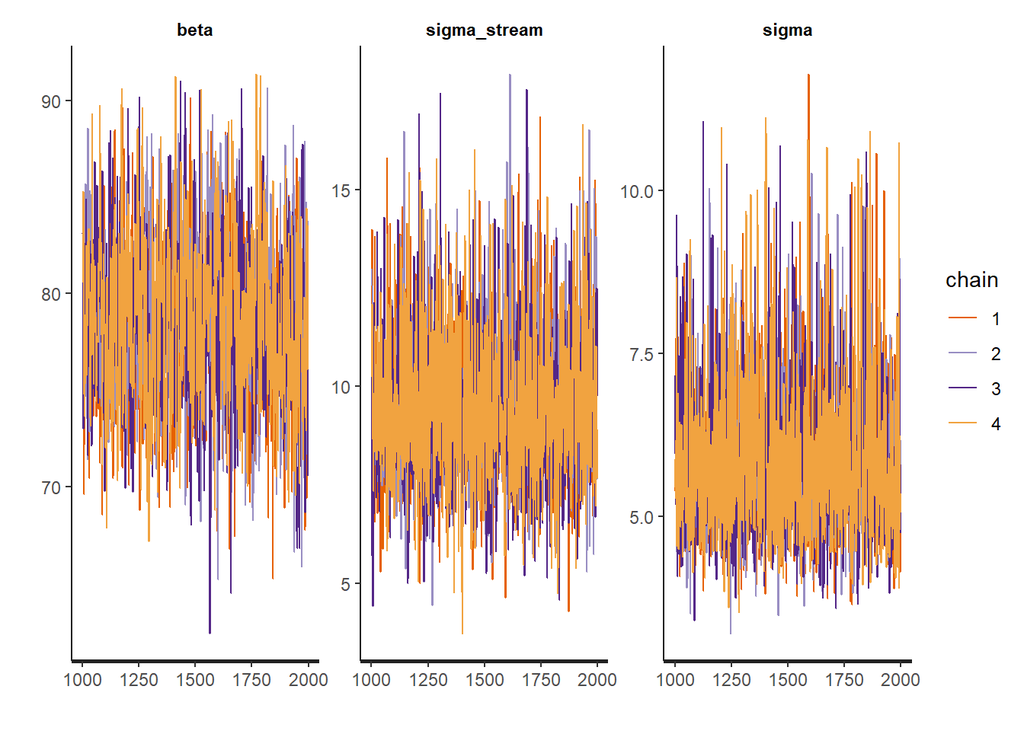

```r
rstan::traceplot(fit, pars = c("beta","sigma_stream","sigma"))
```

What does this look like compared to `nlme()`

```r
lm3 <- nlme::lme(fixed = Density ~ 1,data=Streams,random = ~ 1 | Stream)
cbind("nlme"=coef(lm3)[[1]],"stan"=ci[1,])
```

```
##        nlme   stan
## [1,] 94.621 93.250
## [2,] 90.901 89.879
## [3,] 89.681 88.769
## [4,] 67.987 68.876
## [5,] 72.500 73.008
## [6,] 56.083 57.893
```

But note that Stan (or Bayesian more generally) actually provides us estimates of uncertainty in our random effects! All for the low low cost of our sanity.

Let’s finish this off with some additional diagnostics.

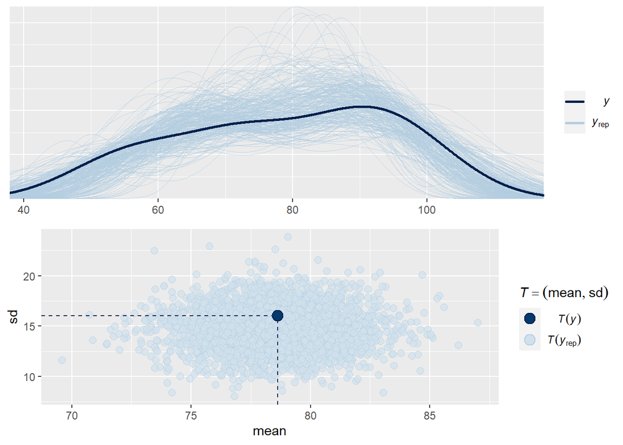

```r
# do a quick pp_check
y_ppd <- extract(fit)$y_ppd
b1 <- bayesplot::ppc_dens_overlay(stan_data$y, y_ppd[sample(1:nrow(y_ppd),250),])
b2 <- bayesplot::ppc_stat_2d(stan_data$y, y_ppd, stat = c("mean", "sd"))
bayes_diag <- ggpubr::ggarrange(b1,b2, ncol = 1,nrow=2)
print(bayes_diag)
```

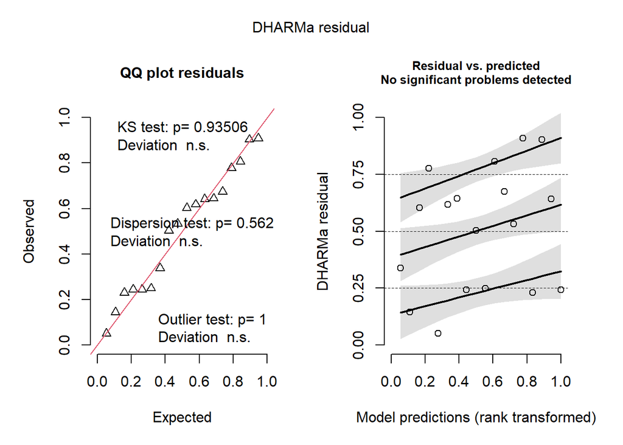

```r
# Dharma residuals
dharma_resids <- function(model, iter, response, y_ppd = "y_ppd"){
  #extract model predictions based on our generated quantities section (the y_ppd variable)
  predictions <- as.data.frame(rstan::extract(model,pars = y_ppd)[[1]]) %>%
    #get things in the right format
    rownames_to_column() %>%
    pivot_longer(!rowname,
                 names_to = "obs",
                 values_to = "y_ppd") %>%
    mutate(rowname = as.numeric(rowname))
  # randomly select 250 draws
  sim_response_matrix <-
    data.frame(rowname = sample(1:iter, 4000, replace = FALSE)) %>%
    #left_join will grab only the rows in predictions that line up with the row
    #names we randomly generated above
    left_join(predictions, by = "rowname") %>%
    #remove obs so we can pivot wider without pissing it off
    dplyr::select(-obs) %>%
    group_by(rowname) %>%
    mutate(row = row_number()) %>%
    #get everything back in the right format
    pivot_wider(id_cols = everything(), names_from = 'rowname', values_from = 'y_ppd') %>%
    dplyr::select(-row) %>%
    as.matrix()
  #calculate the residuals using the simulated responses and the actual raw data
  resids <- DHARMa::createDHARMa(simulatedResponse = sim_response_matrix,
                                 observedResponse = response,
                                 fittedPredictedResponse = apply(t(sim_response_matrix), 2, mean),
                                 integerResponse = FALSE)
  return(resids)
}

#run our custom function on our model and with our raw data
resids <- dharma_resids(fit, iter=nrow(y_ppd), stan_data$y)
plot(resids)
```